# Medidas de tendencia central

[Jose Enrique Puga Mañe](https://josenriquepuga.github.io)

Estadística 2022-2, [Facultad de economía](http://www.economia.unam.mx/)

2/3/2022

### 1. ¿Qué son las medidas de tendencia central? 🤔

> Definición: “**Las medidas de tendencia central son parámetros estadísticos que informan sobre el centro de la distribución de la [muestra](https://economipedia.com/definiciones/muestra-estadistica.html)o [población estadística](https://economipedia.com/definiciones/poblacion-estadistica.html)“**

Fuente[Economipedia “2022”](https://economipedia.com/definiciones/medidas-de-tendencia-central.html)

Para este ejemplo, primero generaremos una serie de **100** números aleatorios entre **1** y **20** mediante la función `sample`. El argumento `TRUE` nos permitirá generar una muestra con remplazo:

```r
numeros <- sample(1:20, 100, TRUE)
numeros
```

[output not shown]

### 2. Mediana 📍

> Definición: “**La mediana es un [estadístico](https://economipedia.com/definiciones/estadistico.html) de posición central que parte la distribución en dos, es decir, deja la misma cantidad de valores a un lado que a otro”**

[Economipedia (2022)](https://economipedia.com/definiciones/mediana.html)

Para obtener la **mediana**, podemos ordenar los `numeros` de menor a mayor, **el número que esté en medio de la muestra será la mediana**. Si utilizamos R, se puede hacer el cálculo de la **mediana** con la función `median`:

```r
mediana <- median(numeros)
mediana
```

```
## [1] 10
```

### 3. Media 🧮

> Definición: “**La media aritmética es un tipo de media que otorga la misma ponderación a todos los valores**”

[Economipedia (2022)](https://economipedia.com/definiciones/media-aritmetica.html)

$$Media ={\frac {1}{n}}\sum _{i=1}^{n}a_{i}={\frac {a_{1}+a_{2}+\cdots +a_{n}}{n}}$$

Si usamos R, podemos obtener la media de una muestra si utlilizamos la función **mean**:

```r
media <- mean(numeros)
media
```

```
## [1] 10.24
```

### 4. Moda 📊

> Definición: “En la [estadística](https://es.wikipedia.org/wiki/Estad%C3%ADstica), la **moda** es el valor que aparece con mayor frecuencia en un conjunto de datos. Esto va en forma de una columna cuando encontremos dos modas, es decir, dos datos que tengan la misma frecuencia absoluta máxima. Una distribución trimodal de los datos es en la que encontramos tres modas”

Wikipedia (2022)

Podemos saber cuál es la **frecuencia** (número de veces que aparece un elemento en una muestra) de cada número si dibujamos un **histograma** con la función `hist`, **aquel elemento con mayor frecuencia será la moda**:

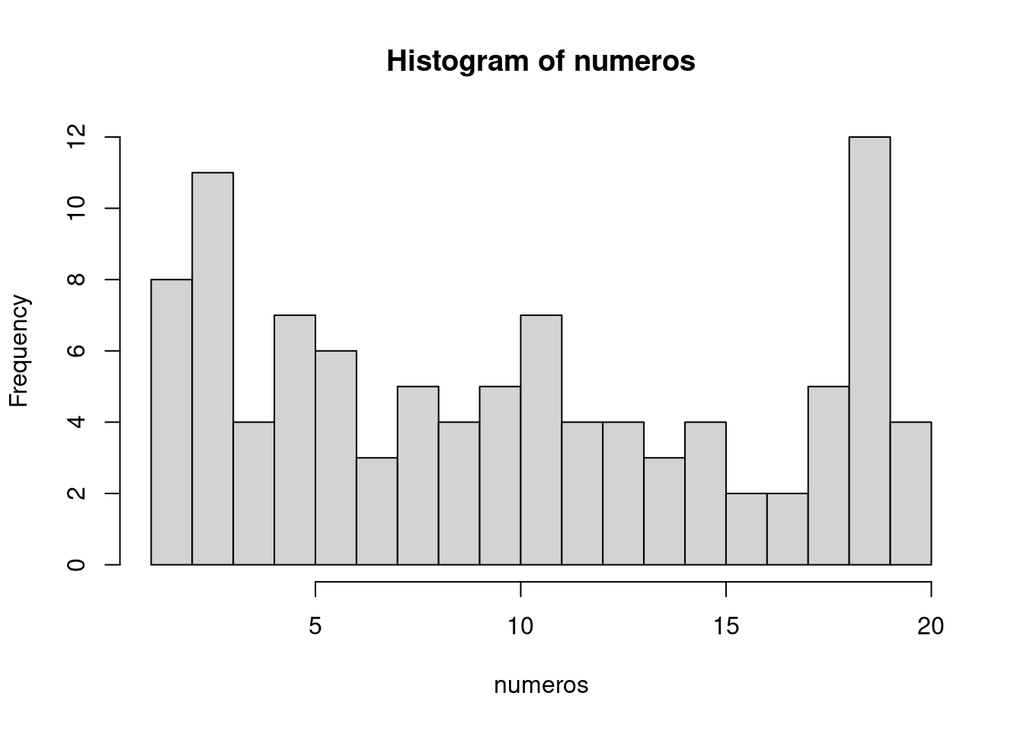

```r
# El argumento breaks nos permite dividir en histograma en las partes que queramos
hist(numeros, breaks = 20)
```

Para obtener un resultado con más precisión, podemos obtener la **moda** si generamos una **tabla de frecuencias** con la función `table` y la función `data.frame`, **aquel elemento con mayor frecuencia será la moda**:

```r
tabla.frecuencias <- data.frame(table(numeros))
tabla.frecuencias
```

```
##    numeros Freq
## 1        1    2
## 2        2    6
## 3        3   11
## 4        4    4
## 5        5    7
## 6        6    6
## 7        7    3
## 8        8    5
## 9        9    4
## 10      10    5
## 11      11    7
## 12      12    4
## 13      13    4
## 14      14    3
## 15      15    4
## 16      16    2
## 17      17    2
## 18      18    5
## 19      19   12
## 20      20    4
```

### 5. Ejercicio 👩‍💻👨‍💻✍

Aplica lo que aprendiste, obten la **mediana**, **media** y **moda** de la siguiente muestra de números:

```r
# Con la función seq, creamos una secuencia de 1 a 10 en intervalos de 0.1 en 0.1
secuencia <- seq(1, 10, 0.1)
muestra <- sample(secuencia, 100, TRUE)
muestra
```

```
##   [1]  6.1  9.1  5.4  5.9  3.0  1.7  7.7  7.1  1.3  9.2  7.4  4.7  4.1  4.1  2.6
##  [16]  6.9  8.3  7.3  4.0  2.1  1.4  4.7  2.4  8.4  3.5 10.0  3.5  3.1  3.4  2.2
##  [31]  4.6  6.8  2.2  8.2  8.9  6.0  9.2  6.6  3.5  4.2  2.3  2.7  2.8  4.4  4.0
##  [46]  7.7  3.9  4.9  7.7  4.7  1.6  5.5  1.7  2.7  8.6  1.2  2.3  3.0  2.3  3.2
##  [61]  7.7  5.0  7.3  1.8  9.7  8.3  2.6  2.5  6.1  3.3  6.7  7.5  8.7  8.4  1.9
##  [76]  1.6  6.5  1.2  6.9  5.2  2.2  2.1  4.1  4.8  4.7  3.2  4.5  8.9  9.3  5.5
##  [91]  9.1  3.4  2.8  1.9  7.5  1.6  5.9  9.6  6.9  5.5
```

##### Mediana

```r
#Aquí el cálculo de la mediana
mediana.muestra <- median(muestra)
mediana.muestra
```

```
## [1] 4.7
```

##### Media

```r
# Aquí el cálculo de la media
media <- mean(muestra)
media
```

```
## [1] 5.004
```

##### Moda

```r
# Aquí el cálculo de la moda
tabla.frecuencias <- data.frame(table(muestra))
tabla.frecuencias
```

```
##    muestra Freq
## 1      1.2    2
## 2      1.3    1
## 3      1.4    1
## 4      1.6    3
## 5      1.7    2
## 6      1.8    1
## 7      1.9    2
## 8      2.1    2
## 9      2.2    3
## 10     2.3    3
## 11     2.4    1
## 12     2.5    1
## 13     2.6    2
## 14     2.7    2
```

[output cut: 46 more lines]

💻[Código disponible en RStudio Cloud](https://rstudio.cloud/project/3671022)💻